# Reddit Data Analysis

# 4. N-grams

An **n-gram** is a sequence of *n* words that appear together. For example:

- “basketball coach” and “dinner time” are bigrams (two words),
- “the three musketeers” is a trigram (three words), and
- “she was very hungry” is a fourgram (four words).

In advanced text analysis and machine learning, specific tokens and n-grams are often used as features for modeling and classification tasks.

N-grams are particularly useful for analyzing **words in context**. Consider these two sentences:

- *“We need to check the details.”*
- *“Can we pay it with a check?”*

The word “*check*” functions as a verb in the first sentence and a noun in the second. We can understand its meaning based on the **surrounding words**, especially those immediately before or after it. For example, when “*check*” follows “*to*”, it’s likely being used as a verb.

As an example of **bigram**, the sentence “*The result of separating bigrams is helpful for exploratory analyses of the text.*” becomes a list of **paired words**:  
1 the result  
2 result of  
3 of separating  
4 separating bigrams  
5 bigrams is  
6 is helpful  
7 helpful for  
8 for exploratory  
9 exploratory analyses  
10 analyses of  
11 of the  
12 the text

```r
# Get ngrams. You may try playing around with the value of n, n=3, n=4
words_ngram <- threads_2 %>%
  mutate(text = str_replace_all(text, replace_reg, "")) %>%
  select(text) %>%
  unnest_tokens(output = paired_words,
                input = text,
                token = "ngrams",
                n = 2)
```

```r
# Show ngrams with sorted values
words_ngram %>%
  count(paired_words, sort = TRUE) %>%
  head(20) %>%
  knitr::kable()
```

| paired_words | n |
| --- | --- |
| NA | 128 |
| in the | 41 |
| i was | 37 |
| the bike | 28 |
| of the | 27 |
| on the | 27 |
| and i | 25 |
| for the | 24 |
| it s | 21 |
| to the | 21 |
| a bike | 18 |
| and the | 18 |
| but i | 18 |
| i am | 17 |
| i m | 17 |
| for a | 16 |
| that i | 15 |
| it was | 14 |
| on a | 14 |
| i had | 13 |

Here, we can see that the n-grams still contain stop words such as a, to, and so on. Next, we’ll extract n-grams without stop words. We can use the `separate` function from the `tidyr` package to split each bigram into two columns: *word 1* and *word 2*. Then, we filter out any rows where either column contains a stop word using the `filter` function.

```r
#separate the paired words into two columns
words_ngram_pair <- words_ngram %>%
  separate(paired_words, c("word1", "word2"), sep = " ")

# filter rows where there are stop words under word 1 column and word 2 column
words_ngram_pair_filtered <- words_ngram_pair %>%
  # drop stop words
  filter(!word1 %in% stop_words$word & !word2 %in% stop_words$word) %>%
  # drop non-alphabet-only strings
  filter(str_detect(word1, "[a-z]") & str_detect(word2, "[a-z]"))

# Filter out words that are not encoded in ASCII
# To see what's ASCII, google 'ASCII table'
library(stringi)
words_ngram_pair_filtered %<>%
  filter(stri_enc_isascii(word1) & stri_enc_isascii(word2))

# Sort the new bi-gram (n=2) counts:
words_counts <- words_ngram_pair_filtered %>%
  count(word1, word2) %>%
  arrange(desc(n))

head(words_counts, 20) %>%
  knitr::kable()
```

| word1 | word2 | n |
| --- | --- | --- |
| bike | shop | 5 |
| feel | free | 4 |
| gravel | bike | 4 |
| bike | lanes | 3 |
| bike | path | 3 |
| en | route | 3 |
| garmin | varia | 3 |
| gas | station | 3 |
| mile | rides | 3 |
| mountain | bike | 3 |
| night | vision | 3 |
| red | axs | 3 |
| waxed | chain | 3 |
| 3d | printed | 2 |
| 3d | printing | 2 |
| bicycle | santa | 2 |
| bike | lane | 2 |
| bike | ride | 2 |
| bike | storage | 2 |
| bike | trip | 2 |

Finally, by using the `igraph` and `ggraph` packages, we can visualize **words occurring in pairs**, which allows us to see common relationships between words in the text.

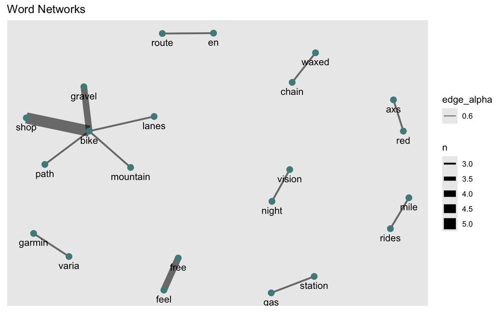

```r
# plot word network
words_counts %>%
  filter(n >= 3) %>%
  graph_from_data_frame() %>% # convert to graph
  ggraph(layout = "fr") +
  geom_edge_link(aes(edge_alpha = .6, edge_width = n)) +
  geom_node_point(color = "darkslategray4", size = 3) +
  geom_node_text(aes(label = name), vjust = 1.8) +
  labs(title = "Word Networks",
       x = "", y = "")
```